# X-11 알고리즘을 활용한 계절 조정 분석

김미정

# X-11 알고리즘 개요

X-11 알고리즘은 시계열 데이터를 **추세(Trend), 계절성(Seasonality), 불규칙 요소(Irregularity)**로 분해하는 방법입니다. 이 알고리즘은 미국 인구조사국(U.S. Census Bureau)에 의해 개발되었으며, 여러 통계 기관에서 계절 조정에 사용됩니다.

X-11 알고리즘은 아래와 같은 방식으로 데이터를 분해합니다.

- **가법 모델 (Additive Model)**:
  $$Y_t = T_t + S_t + I_t$$
- **승법 모델 (Multiplicative Model)**:
  $$Y_t = T_t \times S_t \times I_t$$

여기서,  
- $T_t$: **추세(Trend)** 또는 **추세-주기(Trend Cycle)** - $S_t$: **계절성(Seasonality)** - $I_t$: **불규칙 요소(Irregularity)**

# X-11 알고리즘의 계절 분해 과정

이 알고리즘은 **중심 이동 평균(centered moving averages)** 을 반복적으로 적용하여 계절 분해를 수행합니다. 월별 시계열 데이터의 가법 분해를 예로 들면, 알고리즘은 다음과 같은 단계를 따릅니다.

### ✅ 1단계: 초기 추세(Trend) 추정

- **13개월 중심 이동 평균(Centered Moving Average, CMA)** 를 계산하여 초기 추세를 추정
- 예를 들어, 시간 $t$의 추세 값은 $t-6$부터 $t+6$까지의 이동 평균을 계산하여 얻음

### ✅ 2단계: 계절+불규칙 성분 (SI) 분리

- 원래 시계열에서 초기 추세 추정값을 빼서 **계절성 + 불규칙 성분(Seasonal + Irregular, SI)** 만 남김
  $$SI_t = Y_t - T_t$$

### ✅ 3단계: 초기 계절성(Seasonality) 추정

- 계절 주기에 따른 이동 평균을 적용하여 초기 계절 성분을 추정
- 예를 들어, 월별 데이터의 경우:
  $$S_t = \text{평균}(SI_{t-24}, SI_{t-12}, SI_t, SI_{t+12}, SI_{t+24})$$
  (즉, 동일한 월의 값들끼리 평균을 계산하여 계절 성분을 추정)

### ✅ 4단계: 초기 계절 조정 데이터 생성

- 원래 시계열에서 초기 계절 성분을 제거하여 계절 조정된 데이터를 생성
  $$Y_t^{\text{adj}} = Y_t - S_t$$

### ✅ 5단계: 향상된 추세(Trend) 추정 (Henderson 필터 적용)

- **Henderson 이동 평균(Henderson Moving Average) 필터**를 적용하여 더욱 정교한 추세를 추정

### ✅ 6단계: 새로운 계절성 추정 및 조정 반복

- 새로운 추세 값을 사용하여 계절 성분을 다시 계산하고, 계절 조정을 반복 수행

### ✅ 7단계: 최종 추세 및 불규칙 성분 추출

- 최종적으로 계절 조정된 데이터에서 추세와 불규칙 성분을 구분하여 분석 완료

# 데이터 로드 및 패키지 설치

먼저, 필요한 패키지를 설치하고 데이터를 불러옵니다.

```r
# 필요한 패키지 설치 (최초 1회만 실행 필요)
if (!requireNamespace("seasonal", quietly = TRUE)) install.packages("seasonal")
library(seasonal)
library(ggplot2)
```

# 샘플 데이터 불러오기

R의 `AirPassengers` 데이터셋을 활용하여 계절 조정을 수행하겠습니다. 이 데이터는 1949년부터 1960년까지의 월별 국제 항공 승객 수를 포함하고 있습니다.

```r
# 데이터 로드
data("AirPassengers")
ts_data <- AirPassengers  # 시계열 데이터

# 데이터 기본 정보 확인
summary(ts_data)
```

```
##    Min. 1st Qu.  Median    Mean 3rd Qu.    Max.
##   104.0   180.0   265.5   280.3   360.5   622.0
```

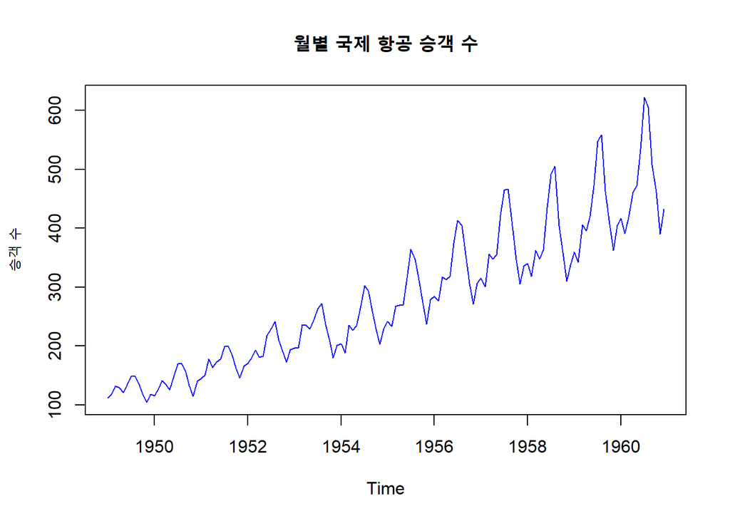

```r
plot(ts_data, main = "월별 국제 항공 승객 수", ylab = "승객 수", col = "blue")
```

# X-11 알고리즘을 활용한 계절 조정

`seasonal` 패키지의 `seas()` 함수를 사용하여 **X-11 계절 조정**을 수행합니다.

```r
# X-11 알고리즘 적용
adjusted_model <- seas(ts_data, x11 = "")

# 계절 조정된 데이터 추출
seasonally_adjusted <- final(adjusted_model)
```

# 결과 시각화

계절 조정 전후의 데이터를 비교하기 위해 시각화를 수행합니다.

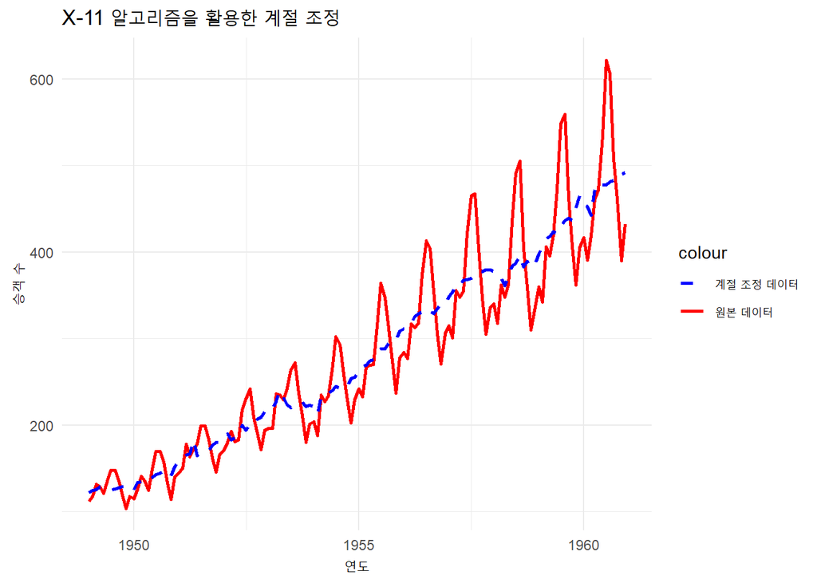

```r
# 원본 데이터와 계절 조정된 데이터 비교
ts_df <- data.frame(
  Date = seq(as.Date("1949-01-01"), by = "month", length.out = length(ts_data)),
  Original = as.numeric(ts_data),
  Adjusted = as.numeric(seasonally_adjusted)
)

ggplot(ts_df, aes(x = Date)) +
  geom_line(aes(y = Original, color = "원본 데이터"), size = 1) +
  geom_line(aes(y = Adjusted, color = "계절 조정 데이터"), size = 1, linetype = "dashed") +
  labs(title = "X-11 알고리즘을 활용한 계절 조정", x = "연도", y = "승객 수") +
  scale_color_manual(values = c("blue", "red")) +
  theme_minimal()
```

# 결론

X-11 알고리즘을 활용하여 계절 조정을 수행한 결과, **반복적인 계절 변동이 제거되어 전체적인 추세(Trend)를 더 명확하게 확인할 수 있습니다.**

X-11 알고리즘은 다양한 경제 및 사회 데이터에서 계절성을 제거하고 장기적인 패턴을 분석하는 데 유용하게 사용됩니다.